# Coursework Report

*N* removed NAs: 7

*N* removed <18: 18

**Correct typo age:** 19

*N* total clean: 143

| Group | *N* | *M*<sub>age</sub> | % green |
| --- | --- | --- | --- |
| Control | 72 | 20.89 | 39.35 |
| Experim | 71 | 21.30 | 60.56 |

| Gender | *N* | *M*<sub>age</sub> | % green |
| --- | --- | --- | --- |
| Female | 66 | 21.06 | 47.47 |
| Male | 49 | 21.08 | 54.42 |
| Other | 28 | 21.18 | 47.62 |

**Main analysis results**

**cleaner:**  
χ<sup>2</sup>(1) = 3.09, *p* = .079

**dishwasher:**  
χ<sup>2</sup>(1) = 4.42, *p* = .035

[interactive chart not shown]

[figure not shown]

[interactive chart not shown]

# Coursework Report

Analysing Data, Spring 2020

# Methods

## Participants

Initially, 168 participants took place and had three observations recorded each, meaning that 504 participants recordings were present. However, due to incomplete data of 22 observations, as well as 18 participants being younger than 18, the adjusted quantity of participants was reduced to 143, with 428 observations recorded. It is essential to remove participants younger than 18, due to ethical reasons, such as a difficulty to obtain informed consent from these people. Participants were aged between 18 and 27, with the mean age being 21.1 years old. In addition, the standard deviation of age was 2.08, meaning that the majority of participants were aged between 19.02 years and 23.18 years old.

```
## # A tibble: 6 x 5
## # Groups:   gender [3]
##   gender condition        n mean_age sd_age
##   <fct>  <fct>        <int>    <dbl>  <dbl>
## 1 female control        110     20.8   2.36
## 2 female experimental    87     21.4   2.37
## 3 male   control         69     20.7   1.87
## 4 male   experimental    78     21.5   1.70
## 5 other  control         36     21.7   1.96
## 6 other  experimental    48     20.8   1.48
```

## Design

The conceptual hypothesis states that people will buy green products due to status motives. The factor variable “id” displays each participants identification code and is assigned to each participant who has three of their choices recorded. Numeric variable “age” displays each participants age and can show whether certain aged individuals are more likely to pick a green product. Factor variable “gender” will provide a measure of whether males, females or other will be more likely to pick a green product. The factor variable “condition” assigns participants to either the control or experimental condition to create more specific measures. The first measure being factor “choice”, in which participants are separated based on whether they have chosen green or luxury for each of the three products. A high score indicates that the participant heavily identifies with the assigned condition. The second measure is the factor variable “product”, in which participants decide whether they would prefer a green or luxurious dishwasher, car and cleaner. This variable measures whether certain products are favoured more as luxurious or green. The operational hypothesis states that participants from the high-status condition are more likely to purchase a green product in comparison to participants from the control condition.

# Results

A common pattern has been displayed amongst all three of the products (at least 56% of participants). Participants in the control condition were more likely to choose a non-green product whereas participants in the high-status were more likely to choose the green product (roughly 60% of participants).

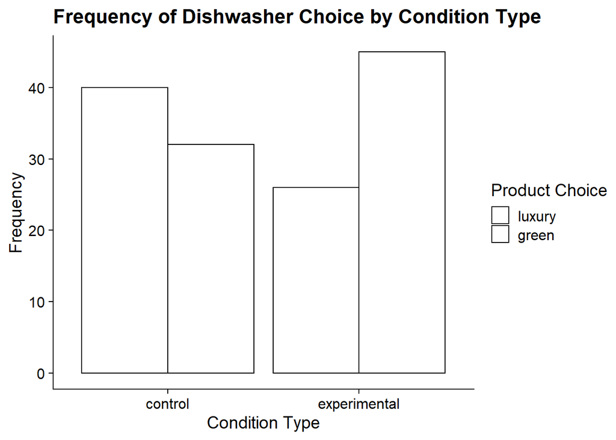

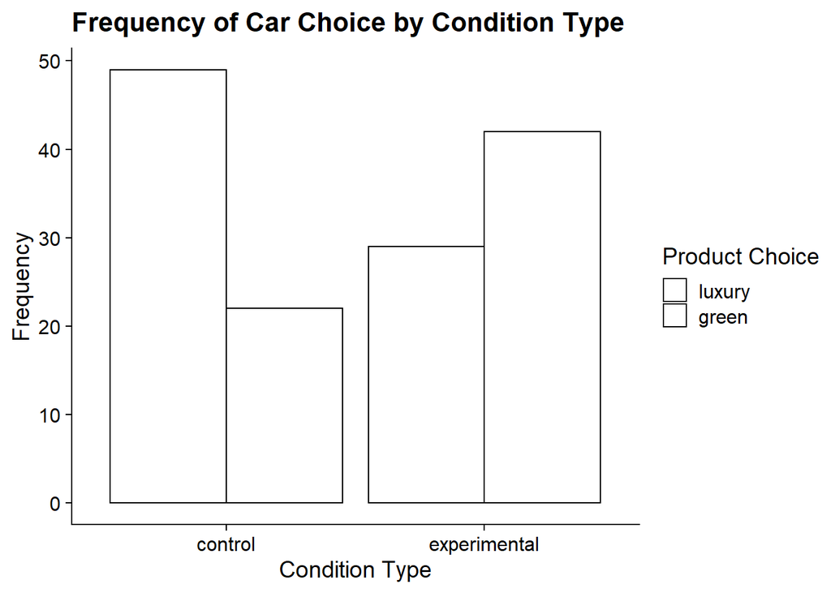

[figure not shown]

```
##
##  Pearson's Chi-squared test with Yates' continuity correction
##
## data:  car_filter
## X-squared = 10.269, df = 1, p-value = 0.001353
```

```
##
##  Pearson's Chi-squared test with Yates' continuity correction
##
## data:  cleaner_filter
## X-squared = 3.0916, df = 1, p-value = 0.0787
```

```
##
##  Pearson's Chi-squared test with Yates' continuity correction
##
## data:  dishwasher_filter
## X-squared = 4.424, df = 1, p-value = 0.03544
```